# MonteCarlo

2022-11-05

```r
library(ggpubr)
```

```r
library(ggplot2)
```

## Prueba de permutaciones para 2 Muestras Independientes

Denotando como σA a la varianza de las calificaciones finales de estudiantes de primer año de Ingeniería en el curso inicial de programación bajo estudio, y como σB a la varianza de las calificaciones finales de estudiantes de último año de otras carreras en el mismo curso, entonces: H0: σA − σB = 0 HA: σA − σB ̸= 0

## Se utiliza un alfa igual a 0.05

```r
set.seed(432)
```

## Funcionpara calcular la diferencia de medias

Argumentos: - muestra_1, muestra_2: vectores numericos con las muestras a comparar - FUN: funcion del estadistico E para el que se calcula la diferencia Valor: - diferencia E_1 - E_2

```r
calcular_diferencia <- function(muestra_1, muestra_2, FUN){
  diferencia <- FUN(muestra_1) - FUN(muestra_2)
  return(diferencia)
}
```

## Funcion para hacer una permutacion y calcular el estadistico

de interes Argumentos: - muestra_1, muestra_2: vectores numericos con las muestras a comparar - FUN: funcion del estadistico E para el que se calcula la diferencia Valor: - diferencia E_1 - E_2

```r
permutar <- function(muestra_1, muestra_2, FUN){
  n_1 <- length(muestra_1)
  n_2 <- length(muestra_2)

  # Hacer la permutacion
  permutacion <- sample(c(muestra_1, muestra_2), size = n_1 + n_2,
                        replace = FALSE)

  # Asignar elementos a los dos grupos
  permutacion_1 <- permutacion[1 : n_1]
  permutacion_2 <- permutacion[n_1 + 1 : n_2]

  # Calcular y devolver la diferencia de medias
  return(calcular_diferencia(permutacion_1, permutacion_2, FUN))
}
```

## Funcion para calcular el valor p

Argumentos: - distribucion: distribucion nula del estadistico de interes - valor observado: valor del estadistico de interes para las muestras originales - repeticiones: cantidad de permutaciones a realizar - alternative: tipo de hipotesis alternativa (“two.sided” para hipotesis bilateral, “greater” o “less” para hipotesis unilaterales) Valor: - el valorp calculado

```r
calcular_valor_p <- function(distribucion, valor_observado,
                             repeticiones, alternative){
  if(alternative == "two.sided"){
    numerador <- sum(abs(distribucion) > abs(valor_observado)) + 1
    denominador <- repeticiones + 1
    valor_p <- numerador / denominador
  }
  else if(alternative == "greater"){
    numerador <- sum(distribucion > valor_observado) + 1
    denominador <- repeticiones + 1
    valor_p <- numerador / denominador
  }
  else{
    numerador <- sum(distribucion < valor_observado) + 1
    denominador <- repeticiones + 1
    valor_p <- numerador / denominador
  }
  return(valor_p)
}
```

## Funcion para graficar una distribucion

Argumentos: - distribucion: distribucion nula el estadistico de interes - …: otros argumentos a ser entregados a gghistogram y ggqqplot

```r
graficar_distribucion <- function(distribucion, ...){
  observaciones <- data.frame(distribucion)

  histograma <- gghistogram(observaciones, x = "distribucion",
                            xlab = "Estadistico de interes",
                            ylab = "Frecuencia", ...)
  qq <- ggqqplot(observaciones, x = "distribucion", ...)

  # Crear una unica figura con todos los graficos de dispersion
  figura <- ggarrange(histograma, qq, ncol = 2, nrow = 1)
  print(figura)
}
```

## Funcion para hacer la prueba de permutaciones

Argumentos : - muestra_1, muestra_2: vectores numericos con las muestras a comparar - repeticiones: cantidad de permutaciones a realizar - FUN: funcion del estadistico E para el que se calcula la diferencia - alternative: tipo de hipotesis alternativa (“two.sided” para hipotesis bilateral, “greater” o “less” para hipotesis unilaterales) - plot: si es TRUE, construye el grafico de la distribucion generada - …: otros argumentos a ser entregados a graficar_distribucion

```r
contrastar_hipotesis_permutaciones <- function(muestra_1, muestra_2,
                                               repeticiones, FUN,
                                               alternative, plot, ...){
  cat("Prueba de permutaciones\n\n")
  cat("Hipotesis alternativa:", alternative, "\n")
  observado <- calcular_diferencia(muestra_1, muestra_2, FUN)
  cat("Valor observado:", observado, "\n")

  distribucion <- rep(NA, repeticiones)

  for(i in 1:repeticiones){
    distribucion[i] <- permutar(muestra_1, muestra_2, FUN)
  }

  if(plot){
    graficar_distribucion(distribucion, ...)
  }

  valor_p <- calcular_valor_p(distribucion, observado, repeticiones,
                              "two.sided")

  cat("Valor p:", valor_p, "\n\n")
}
```

Denotando como Ua al promedio de calificaciones finales de estudiantes de primer año de Ingenieria en el curso inicial de programacion bajo estudio, y como Ub al promedio de calificaciones finales de estudiantes de ultimo año de otras carreras en el mismo curso, entonces las hipotesis a formular son: H0: Ua - Ub = 0 HA: Ua - Ub != 0 Se obtiene un p = 0.969, por tanto, se concluye con un 95% de confianza que no existe diferencia entre las calificaciones finales de ambos grupos de estudiantes Se ha decidido realizar un nuevo esudio con las mismas muestras, comparando ahora la diferencia en la variabilidad (manteniendo la misma cantidad de repeticiones e igual nivel de significacion Denotando como Oa a la varianza de las calificaciones finales de estudiantes de primer año de Ingenieria en el curso inicial de programacion bajo estudio, y como Ob a la varianza de las calificaciones finales de estudiantes de ultimo año de otras carreras en el mismo curso, entonces las hipotesis a formular son: H0: Oa - Ob = 0 HA: Oa - Ob != 0 Se obteine un p = 0.003, evidencia suficiente para rechazar la hipotesis nula en avor de la hipotesis alternativa.

## Crear muestras iniciales

```r
a <- c(5.4, 4.7, 6.3, 2.9, 5.9, 5.1, 2.1, 6.2, 1.6, 6.7, 3.0, 3.3,
       5.0, 4.1, 3.3, 3.4, 1.2, 3.8, 5.8, 4.2)
b <- c(4.0, 4.1, 4.3, 4.3, 4.3, 4.2, 4.3, 4.3, 4.4, 4.1, 4.3, 4.0)
```

## Hacer pruebas de permutciones para la media y la varianza

```
## Prueba de permutaciones
##
## Hipotesis alternativa: two.sided
## Valor observado: -0.01666667
```

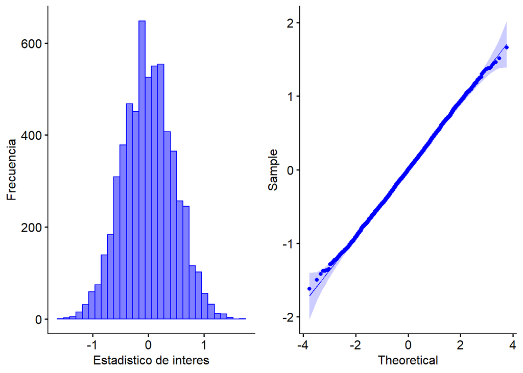

```
## Valor p: 0.9693333
```

```r
R = 5999
contrastar_hipotesis_permutaciones(a, b, repeticiones = R, FUN = mean,
                                   alternative = "two.sided", plot = TRUE,
                                   color = "blue", fill = "blue")
```

```r
contrastar_hipotesis_permutaciones(a, b, repeticiones = R, FUN = var,
                                   alternative = "two.sided", plot = FALSE)
```

```
## Prueba de permutaciones
##
## Hipotesis alternativa: two.sided
## Valor observado: 2.560016
## Valor p: 0.003
```

## CONCLUSIÓN

Tras efectuar el contraste de hipótesis, obtiene como resultado p = 0, 003, evidencia suficiente para rechazar la hipótesis nula en favor de la hipótesis alternativa. Así, el profesor concluye que su percepción no es del todo errada, puesto que la variabilidad de las calificaciones es significativamente mayor para los estudiantes de Ingeniería.